# ÍNDICE DE DESENVOLVIMENTO HUMANO MUNICIPAL 2010- análise comparativa entre educação e renda

29/10/2018

## 1. Introdução

Criado em 1990, para o Relatório de Desenvolvimento Humano do Programa das Nações Unidas para o Desenvolvimento, o Índice de Desenvolvimento Humano (IDH) é uma medida composta de indicadores de saúde, educação e renda. Ele foi criado como uma alternativa às avaliações puramente econômicas de progresso nacional, a partir do crescimento do Produto Interno Bruto (PIB). O índice varia entre 0 (valor mínimo) e 1 (valor máximo). A composição do IDH parte d pressuposto que para viver plenamente as pessoas precisam pelo menos ter a possibilidade de levar uma vida longa e saudável, acesso a conhecimento e a oportunidade de desfrutar de um padrão de vida digno.

O Índice de Desenvolvimento Humano Municipal - IDHM ajusta o IDH para a realidade dos municípios refletindo as especificidades e desafios de cada localidade. O Brasil foi um dos países pioneiros ao, em 1998, adaptar e calcular o IDH para todos os municípios brasileiros.

## Assim, o IDHM é um índice que permite conhecer a realidade do desenvolvimento humano do território brasileiro, bem como populariza a ideia de que desenvolvimento não se resume à perspectiva do crescimento econômico. Além disso, o índice facilita a comparação entre localidades, instrumentalizando a sociedade sobre o estado da qualidade de vida nas unidades federativas, municípios e regiões metropolitanas brasileiras, estimulando a concertação de atores de forma a protagonizar atividades e políticas inovadoras para a superação dos desafios locais rumo ao desenvolvimento humano.

Diante do exposto e considerada a importância do IDHM para análise de políticas públicas, este trabalho apresenta uma análise dos principais indicadores que compõem o IDHM_2010.

## 2.1 Importando os dados

Os dados do IDHM_2010 foram importados utilizando o comamdo read.csv. Como os dados da planilha CSV de origem estão separados por ",", foi utilizado o comando sep = ",". Apesar de ter sido utilizado o comando "encoding = "UFT-8" para corrigir os caracteres com acento, os caracteres com acento aparecerão desconfigurados, pois eles não foram corrigidos na origem.

## 2.2 Para conhecer o conteúdo do arquivo importado foi utilizado o comando "glimpse". Esse comando apresenta o conteúdo das primeiras linhas e colunas do arquivo importado

```
## Observations: 5,565
## Variables: 7
## $ posicao          <int> 1, 2, 3, 4, 4, 6, 7, 8, 9, 10, 11, 12, 13, 14...
## $ Nome             <fct> S�o Caetano do Sul , �guas de S�o Pedro , Flo...
## $ uf               <fct> SP, SP, SC, ES, SC, SP, RJ, SC, DF, PR, SP, S...
## $ IDHM_.2010.      <dbl> 0.862, 0.854, 0.847, 0.845, 0.845, 0.840, 0.8...
## $ IDHM_Renda       <dbl> 0.891, 0.849, 0.870, 0.876, 0.854, 0.861, 0.8...
## $ IDHM_Longevidade <dbl> 0.887, 0.890, 0.873, 0.855, 0.894, 0.852, 0.8...
## $ IDHM_Educacao    <dbl> 0.811, 0.825, 0.800, 0.805, 0.789, 0.807, 0.7...
```

## 2.3 Apresentar o IDHM_Educação do município com maior IDHM_renda

```
##    posicao                 Nome uf IDHM_.2010. IDHM_Renda IDHM_Longevidade
## 1        1  S�o Caetano do Sul  SP       0.862      0.891            0.887
## 2        7             Niter�i  RJ       0.837      0.887            0.854
## 3        4             Vit�ria  ES       0.845      0.876            0.855
## 4       16 Santana de Parna�ba  SP       0.814      0.876            0.849
## 5        3       Florian�polis  SC       0.847      0.870            0.873
## 6       28        Porto Alegre  RS       0.805      0.867            0.857
## 7       17           Nova Lima  MG       0.813      0.864            0.885
## 8        9            Bras�lia  DF       0.824      0.863            0.873
## 9        6              Santos  SP       0.840      0.861            0.852
## 10       4  Balne�rio Cambori�  SC       0.845      0.854            0.894
##    IDHM_Educacao
## 1          0.811
## 2          0.773
## 3          0.805
## 4          0.725
## 5          0.800
## 6          0.702
## 7          0.704
## 8          0.742
## 9          0.807
## 10         0.789
```

## 2.4 Apresentar o IDHM_Renda do município com maior IDHM_Educação

```
##                   Nome IDHM_Renda IDHM_Educacao
## 1  �guas de S�o Pedro       0.849         0.825
## 2  S�o Caetano do Sul       0.891         0.811
## 3              Santos       0.861         0.807
## 4             Vit�ria       0.876         0.805
## 5       Florian�polis       0.870         0.800
## 6  Balne�rio Cambori�       0.854         0.789
## 7          Araraquara       0.788         0.782
## 8       Ilha Solteira       0.786         0.782
## 9               Assis       0.771         0.781
## 10           Cruz�lia       0.698         0.778
```

## 2.5 Apresentar a média do IDHM_Educação de todos as UFs

```
## # A tibble: 27 x 2
##    uf    IDHM_Educacao
##    <fct>         <dbl>
##  1 DF            0.742
##  2 SP            0.676
##  3 SC            0.637
##  4 RJ            0.621
##  5 PR            0.611
##  6 RS            0.601
##  7 GO            0.596
##  8 ES            0.591
##  9 MT            0.577
## 10 MS            0.557
## # ... with 17 more rows
```

## 2.7 variação média IDHM_Renda e IDHM_Educacao

Foi feito um gráfico de barras comparando a variação média IDHM_Renda e IDHM_Educacao

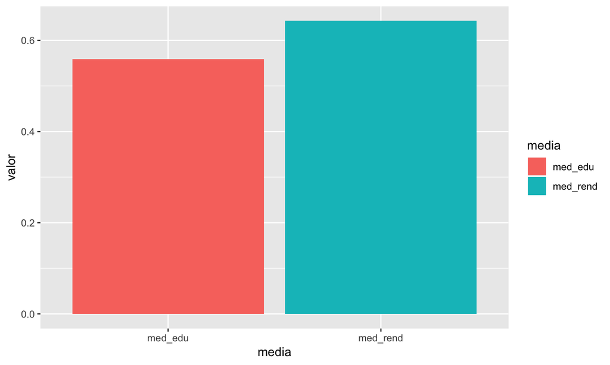